# Using the SpatialBall package

Derek Corcoran

2017-10-02

The `SpatialBall` package was developed to visualize and analyze baketball data from the NBA, we will start by presenting several of our visualization functions, and later we will present our analysis tools

## Visualization Tools

### Season visualization tools:

#### ShotSeasonGraph

This function make the classic shot charts developed by Kirk Goldsberry, the default shows an hexagon in each point of the court, the bigger the hexagons, the more frequent the shots are, and the smaller the hexagons the least frequent the shots are. Also the color scale, in this case, shows the points per shot.

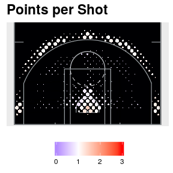

```r
library(SpatialBall)
data("season2017")
ShotSeasonGraph(Seasondata = season2017)
```

for `ShotSeasonGraph` you have two options for the Type of graph, the default (Shown above) is Points per Shot, you can change that to *PCT* to see the shooting percentage:

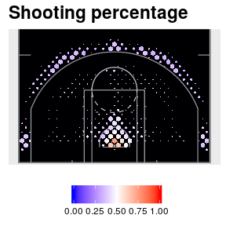

```r
data("season2017")
ShotSeasonGraph(Seasondata = season2017, type = "PCT")
```

another option fot this function is the quantile threshold of which shots are ploted, the default is 0.4, that means that the 40% least common shots are not ploted, if we increase that number, less hexagons will be shown.

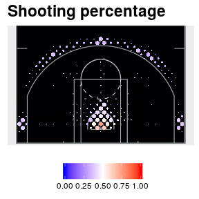

```r
data("season2017")
ShotSeasonGraph(Seasondata = season2017, type = "PCT", quant = 0.6)
```

### Team visualization tools:

We have 2 functions for the visualization of team shot charts `DefShotSeasonGraphTeam`and `OffShotSeasonGraphTeam`, both of them are similar to the `ShotSeasonGraph` function, but focus on one team, and let’s you get the offensive or deffensive shot chart for each team in either Point per shot (type = “PPS”) or percentage (type = “PCT”).

### DefShotSeasonGraphTeam:

These are examples of Charlotte’s deffensive Shot Charts as PPS and PCT

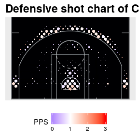

```r
DefShotSeasonGraphTeam(season2017, team = "Cha")
```

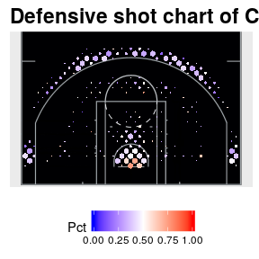

```r
DefShotSeasonGraphTeam(season2017, team = "Cha", type = "PCT")
```

## Styles

```
output:
  rmarkdown::html_vignette:
    css: mystyles.css
```

## Figures

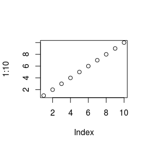

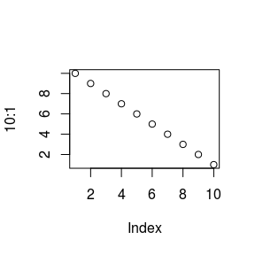

```r
plot(1:10)
plot(10:1)
```

You can enable figure captions by `fig_caption: yes` in YAML:

```
output:
  rmarkdown::html_vignette:
    fig_caption: yes
```

Then you can use the chunk option `fig.cap = "Your figure caption."` in **knitr**.

## More Examples

| GRID_TYPE | GAME_ID | GAME_EVENT_ID | PLAYER_ID | PLAYER_NAME | TEAM_ID | TEAM_NAME | PERIOD | MINUTES_REMAINING | SECONDS_REMAINING | EVENT_TYPE | ACTION_TYPE | SHOT_TYPE | SHOT_ZONE_BASIC | SHOT_ZONE_AREA | SHOT_ZONE_RANGE | SHOT_DISTANCE | LOC_X | LOC_Y | SHOT_ATTEMPTED_FLAG | SHOT_MADE_FLAG | GAME_DATE | HTM | VTM |
| --- | --- | --- | --- | --- | --- | --- | --- | --- | --- | --- | --- | --- | --- | --- | --- | --- | --- | --- | --- | --- | --- | --- | --- |
| Shot Chart Detail | 0021600001 | 2 | 201565 | Derrick Rose | 1610612752 | NY | 1 | 11 | 40 | Made Shot | Driving Layup Shot | 2PT Field Goal | Restricted Area | Center(C) | Less Than 8 ft. | 0 | 4 | 8 | 1 | 1 | 2016-10-25 | Cle | NY |
| Shot Chart Detail | 0021600001 | 3 | 201567 | Kevin Love | 1610612739 | Cle | 1 | 11 | 26 | Missed Shot | Hook Shot | 2PT Field Goal | Restricted Area | Center(C) | Less Than 8 ft. | 3 | -11 | 36 | 1 | 0 | 2016-10-25 | Cle | NY |
| Shot Chart Detail | 0021600001 | 5 | 2546 | Carmelo Anthony | 1610612752 | NY | 1 | 11 | 16 | Missed Shot | Jump Shot | 2PT Field Goal | Mid-Range | Right Side Center(RC) | 16-24 ft. | 19 | 148 | 129 | 1 | 0 | 2016-10-25 | Cle | NY |
| Shot Chart Detail | 0021600001 | 7 | 204001 | Kristaps Porzingis | 1610612752 | NY | 1 | 11 | 15 | Made Shot | Tip Layup Shot | 2PT Field Goal | Restricted Area | Center(C) | Less Than 8 ft. | 2 | 24 | -1 | 1 | 1 | 2016-10-25 | Cle | NY |
| Shot Chart Detail | 0021600001 | 8 | 2544 | LeBron James | 1610612739 | Cle | 1 | 10 | 59 | Made Shot | Jump Shot | 2PT Field Goal | In The Paint (Non-RA) | Left Side(L) | 8-16 ft. | 11 | -79 | 80 | 1 | 1 | 2016-10-25 | Cle | NY |
| Shot Chart Detail | 0021600001 | 10 | 202681 | Kyrie Irving | 1610612739 | Cle | 1 | 10 | 46 | Missed Shot | Jump Shot | 3PT Field Goal | Above the Break 3 | Right Side Center(RC) | 24+ ft. | 24 | 107 | 223 | 1 | 0 | 2016-10-25 | Cle | NY |
| Shot Chart Detail | 0021600001 | 12 | 201584 | Courtney Lee | 1610612752 | NY | 1 | 10 | 34 | Missed Shot | Jump Shot | 2PT Field Goal | Mid-Range | Left Side Center(LC) | 16-24 ft. | 17 | -109 | 141 | 1 | 0 | 2016-10-25 | Cle | NY |
| Shot Chart Detail | 0021600001 | 14 | 201567 | Kevin Love | 1610612739 | Cle | 1 | 10 | 21 | Missed Shot | Jump Shot | 3PT Field Goal | Above the Break 3 | Left Side Center(LC) | 24+ ft. | 25 | -191 | 164 | 1 | 0 | 2016-10-25 | Cle | NY |
| Shot Chart Detail | 0021600001 | 18 | 2747 | JR Smith | 1610612739 | Cle | 1 | 9 | 59 | Made Shot | Cutting Layup Shot | 2PT Field Goal | Restricted Area | Center(C) | Less Than 8 ft. | 0 | -1 | 2 | 1 | 1 | 2016-10-25 | Cle | NY |
| Shot Chart Detail | 0021600001 | 19 | 204001 | Kristaps Porzingis | 1610612752 | NY | 1 | 9 | 47 | Missed Shot | Jump Shot | 2PT Field Goal | Mid-Range | Left Side(L) | 16-24 ft. | 16 | -150 | 61 | 1 | 0 | 2016-10-25 | Cle | NY |